# 605-HW11-Regression

Michael Y.

November 10, 2019

# HW11 - Regression

Using the “cars” dataset in R, build a linear model for stopping distance as a function of speed and replicate the analysis of your textbook chapter 3 (visualization, quality evaluation of the model, and residual analysis.)

```r
cars <- datasets::cars
attach(cars)
# Summary of cars dataset
summary(cars)
```

```
##      speed           dist
##  Min.   : 4.0   Min.   :  2.00
##  1st Qu.:12.0   1st Qu.: 26.00
##  Median :15.0   Median : 36.00
##  Mean   :15.4   Mean   : 42.98
##  3rd Qu.:19.0   3rd Qu.: 56.00
##  Max.   :25.0   Max.   :120.00
```

```r
numrows = dim(cars)[1]
```

There are 50 observations of speed and stopping distance.

## 3.1 Visualize the Data

### Scatterplot

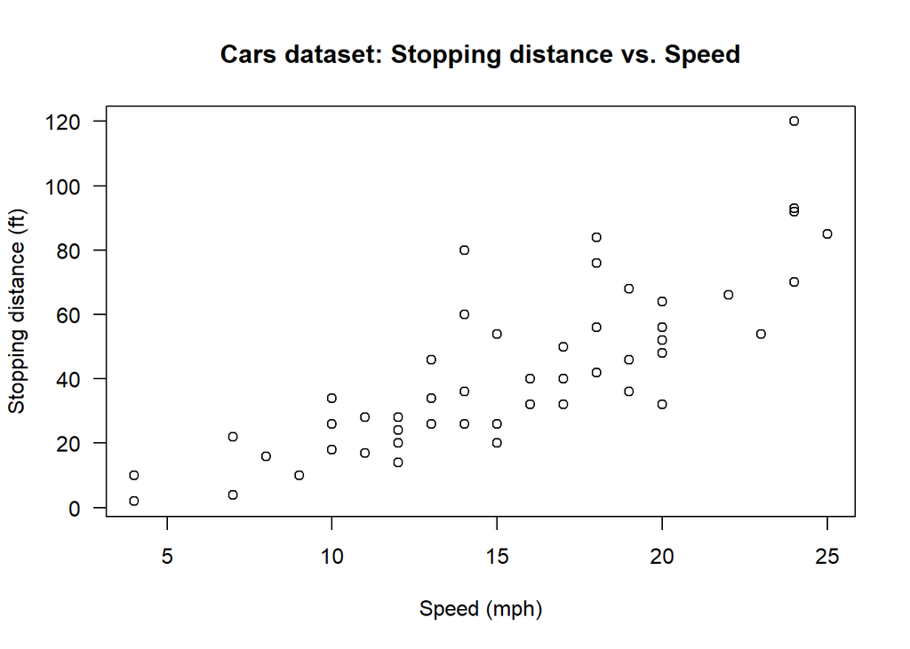

```r
# scatterplot
require(stats); require(graphics)
plot(cars, xlab = "Speed (mph)", ylab = "Stopping distance (ft)", las = 1)
title(main = "Cars dataset: Stopping distance vs. Speed")
```

### Boxplot

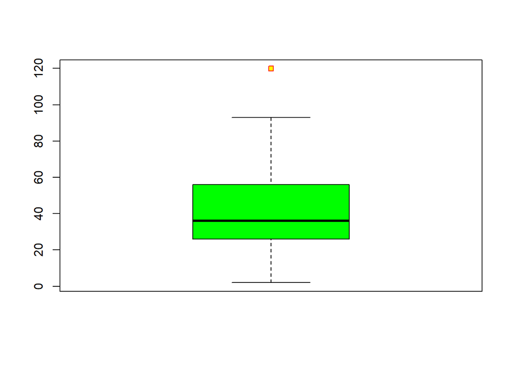

```r
bplot = boxplot(cars$dist,col = "green",outpch=22, outcol="red", outbg="yellow", plot = T)
```

```r
outliers = bplot$out
outliers
```

```
## [1] 120
```

There is an outlier at Stopping Distance = 120.

## 3.2 The Linear Model Function

### Linear model: dist ~ speed

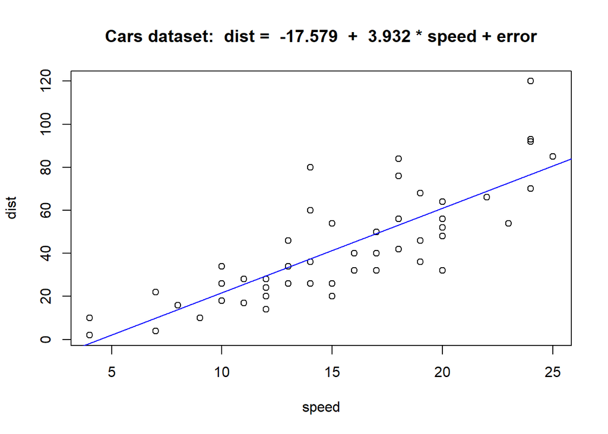

```r
LinearModel <- lm(dist ~ speed, data = cars)
intercept = round(LinearModel$coefficients[1], 3)
slope =     round(LinearModel$coefficients[2], 3)
formula = paste ("dist = ", intercept, " + ", slope, "*", "speed + error")
plot(x = speed, y = dist,
     main=paste("Cars dataset: ", formula))
abline(reg = LinearModel,col="blue")
```

The intercept is negative, which means that at very low speeds, the predicted stopping distance would be negative.  
(Of course, in reality, this is not possible…)

## 3.3 Evaluating the Quality of the Model

```r
summary(LinearModel)
```

```
##
## Call:
## lm(formula = dist ~ speed, data = cars)
##
## Residuals:
##       Min        1Q    Median        3Q       Max
## -29.06908  -9.52532  -2.27185   9.21472  43.20128
##
## Coefficients:
##               Estimate Std. Error  t value           Pr(>|t|)
## (Intercept) -17.579095   6.758440 -2.60106           0.012319 *
## speed         3.932409   0.415513  9.46399 0.0000000000014898 ***
## ---
## Signif. codes:  0 '***' 0.001 '**' 0.01 '*' 0.05 '.' 0.1 ' ' 1
##
## Residual standard error: 15.3796 on 48 degrees of freedom
## Multiple R-squared:  0.651079,   Adjusted R-squared:  0.64381
## F-statistic: 89.5671 on 1 and 48 DF,  p-value: 0.00000000000148984
```

The model shows strong significance at 99% confidence on the slope of the speed parameter, but the intercept is significant only at 95% confidence.

The $R^2$ indicates that the model explains about 65 percent of the variance, which is reasonably good.  
This figure corresponds to correlation, $R$, of about 80 percent between the variables.